# Lección 16 — Gantt y grafos: ida y vuelta

Del PERT o el Roy al diagrama de Gantt, y del Gantt con flechas al cuadro, al Roy y al PERT

## Qué se aprende

A leer y construir las tres representaciones de un mismo proyecto (cuadro de prelaciones, grafos y diagrama de Gantt) y a pasar de cualquiera de ellas a las otras, sabiendo qué información conserva cada una y cuál pierde.

## Las tres representaciones

|  | Qué muestra | Qué no muestra |
| --- | --- | --- |
| Cuadro de prelaciones | la relación de orden, exacta | nada visual: ni tiempos ni estructura |
| Grafo PERT | la estructura con nodos-suceso; las rutas se ven; los tiempos van en los nodos | necesita ficticias; no está a escala |
| Grafo Roy | una actividad por nodo, una prelación por arco; fechas en el nodo | no está a escala; con muchas prelaciones se enreda |
| Gantt (con flechas) | la escala temporal: duración, huecos, solapes; cada prelación inmediata es una flecha | las holguras totales (sólo se ven las libres); sin flechas, ni siquiera las prelaciones |

## Del Gantt al grafo

Si el Gantt lleva flechas de prelación, contiene toda la información: la duración de cada actividad es la longitud de su barra; sus predecesoras inmediatas son las actividades de las que recibe flecha; las iniciales no reciben ninguna (y empiezan en 0); las finales no emiten. De ahí al cuadro, al Roy (inmediato) y al PERT (con el mínimo de ficticias, lección 02). El PERT necesita ficticias donde el Gantt no, porque dibuja cada prelación como una flecha independiente mientras el PERT obliga a que un arco salga de un único nodo.

Si el Gantt **no** lleva flechas, el cuadro *no* queda determinado: sólo se sabe que $P$ puede ser predecesora de $A$ si $EF_P \le ES_A$, y que toda actividad no inicial tiene al menos una predecesora «ajustada» ($EF_P = ES_A$) en un calendario de inicios tempranos. Las prelaciones con hueco son invisibles, y una coincidencia de fechas puede parecer una prelación sin serlo (lección 04, variante *gantt-dado*).

## Ejemplo guía

Los dos grafos del proyecto guía, dibujados por la librería:

[figure not shown]

Grafo PERT con tiempos de los nodos y camino crítico

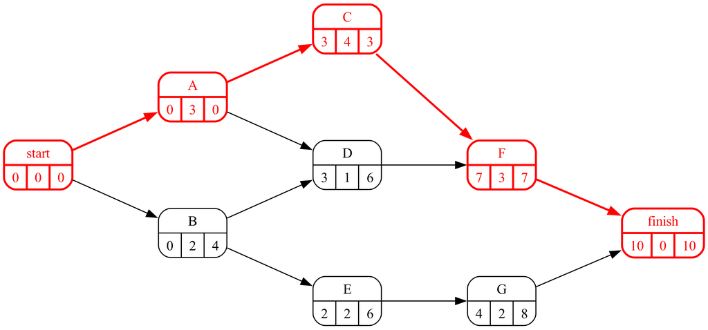

Grafo Roy con fechas y camino crítico

Gantt de inicios más tempranos (semanas), con una flecha por prelación inmediata y la holgura total en la última columna:

[figure not shown]

Gantt de inicios más tempranos

Flechas: A → C, A → D, B → D, B → E, C → F, D → F, E → G (rojas: A → C y C → F). Huecos: D termina en 4 y F empieza en 7 (holgura libre 3); G termina en 6 y el proyecto en 10 (libre 4); B termina en 2 y E empieza en 2 (libre 0, aunque su holgura total es 4). Gantt tardío: B en 5–6, E en 7–8, G en 9–10, D en 7; las esperas insertadas son 4 para B ($LS_B = 4$, inicial), 0 para E ($LS_E - LF_B = 6 - 6$), 0 para D ($LS_D - \max(LF_A, LF_B) = 6 - 6$) y 0 para G ($LS_G - LF_E = 8 - 8$). Se ve que la espera de E y la de D son cero aunque sus holguras totales sean 4 y 3: la holgura la ha consumido B.

[figure not shown]

Gantt de inicios más tardíos (las filas 💤 son las esperas insertadas)

## Con pmULE

```python
g, dibujo = proyecto.gantt(datos, 'duration', holguras=True, tikz=True)   # flechas por defecto; columna H_total
pinta_tikz(dibujo)
# Gantt tardío: proyecto auxiliar con esperas como actividades (ver la variante roy-a-gantt)
```

## Qué practica cada variante

*pert-a-gantt* y *roy-a-gantt*: del grafo sin tiempos (más duraciones) al cuadro, el calendario y los Gantt temprano y tardío. *gantt-a-roy* y *gantt-a-pert*: del Gantt con flechas al cuadro y al grafo; qué holguras se leen en el Gantt y por qué el PERT necesita ficticias.